# Erratum - Summary Analysis

## Overview

Several EPF pH values were rearranged among individuals between when the raw data was collected and the pH values were corrected for the final publication. This rearrangement only impacted a small number of samples that were not the focal timepoints for the manuscript, which is why this error was missed in final quality control check prior to publication. Below is a visualization of this error and a demonstration that this rearrangement did not substantially impact final publication results or conclusions.

## Impact of EPF pH rearrangement on results and conclusions

The overall impact of the EPF pH correction is very mild and only had a slight impact on the visual patterns of EPF pH response through time, particularly at timepoint 1 (24H). However, in both versions of the data we observed no significant differences in EPF pH at that timepoint, indicating the rearrangement had no effect on our interpretation of the results.

## Visualizing Correction

### Packages and Data

**Packages**

```r
library(dplyr,quietly = T,warn.conflicts = F)
library(reshape2,quietly = T)
library(ggplot2,quietly = T)
library(cowplot,quietly = T)
```

### **Data**

```r
# Raw EPF pH values
raw_epf <- read.csv("~/Github/AE17_Cvirginica_MolecularResponse/erratum/comparison_data/AE17_EPF.csv")
# Corrected EPF pH from original published dataset
corrected_epf <- read.csv("~/Github/AE17_Cvirginica_MolecularResponse/data/Phenotype/AE17_EPFpHData_ExperimentalExposureSamples_Simple.csv")
# Updated Corrected EPF pH values
fixed_corrected_epf <- read.csv("~/Github/AE17_Cvirginica_MolecularResponse/erratum/comparison_data/AE17_EPFpHData_CRMCorrected_Aug2020_ADWversion_July2021.csv")
```

## Summary of differences in measure EPF in published (corrected) datasheet compared to original (raw) datasheet

Below are several figures that highlight several EPF pH measures that deviate between the original datasheet, representing the pH values at the time of collection, and the published datasheet, that represents the measured and corrected values that were published and used for all analyses in the publication. Overall, EPF pH values appear to be conserved between the original and published datasheets indicating that differences between the two datasheets observed below was due to values being accidentally rearranged between datasheets.

### Figure 1: Published EPF pH vs. RAW EPF pH

Here we can see that several points deviate from the 1:1 line, indicating that raw pH samples were rearranged during the correction step. Most points that deviate from this line correspond to Timepoint 1, which corresponds to oysters collected 24H after the start of the experimental exposure.

*Note* : Minor deviations from this 1:1 line reflect small rounding errors between the raw datasheet and the corrected datasheet.

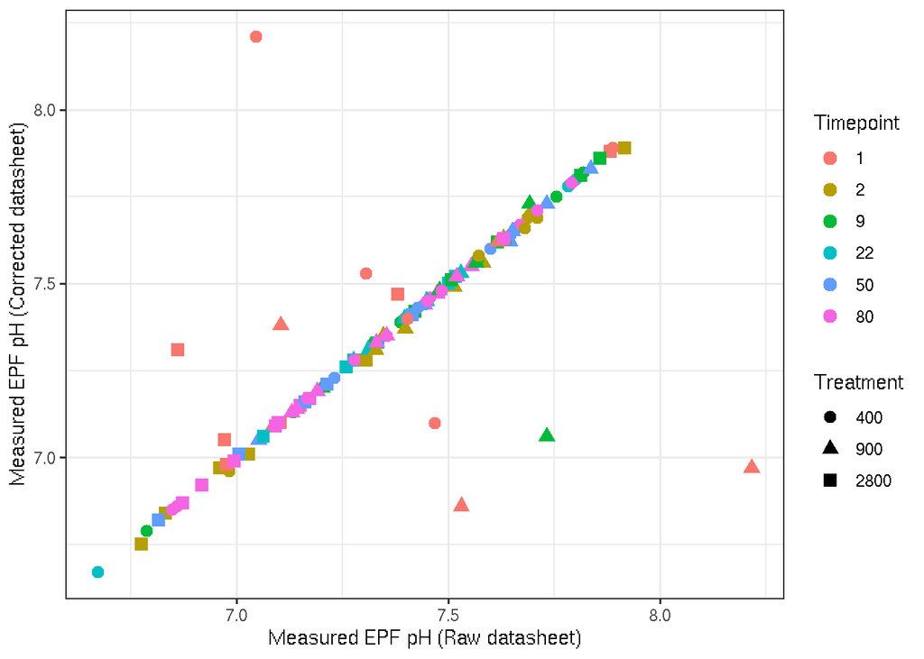

### Figure 2: Corrected EPF pH vs. RAW EPF pH

Here all points fall along 1:1 line indicating the measured pH in the revised EPF datasheet matches the measured EPF pH from the original datasheet.

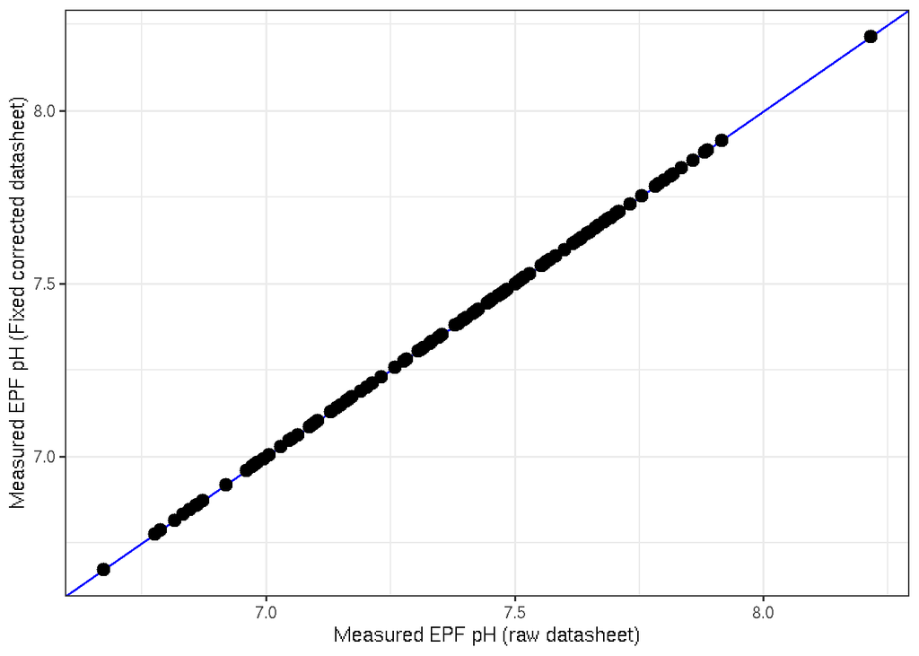